# Select variables to plot a heatmap

Jim Zhang

2016-08-09

**Introduction** This analysis runs a simple procedure that identifies variables significantly different across sample groups via ANOVA and then plots a heatmap of these variables.

*[Go to project home](http://www.ncbi.nlm.nih.gov/geo/query/acc.cgi?acc=GSE67426)*

# 1 Description

## 1.1 Project

Comparison between cell lines from 9 different cancer tissues (NCI-60); **GSE5949**

## 1.2 PubMed

Reinhold WC, Reimers MA, Lorenzi P, Ho J et al. **Multifactorial regulation of E-cadherin expression: an integrative study.** Mol Cancer Ther 2010 Jan;9(1):1-16. PMID: 20053763.

## 1.3 Experimental design

Comparison between cell lines from 9 different cancer tissue of origin types (Breast, Central Nervous System, Colon, Leukemia, Melanoma, Non-Small Cell Lung, Ovarian, Prostate, Renal) from NCI-60 panel

## 1.4 Analysis

Cluster genes co-expressed acroo 9 tissues/organs

*[Go to project home](http://www.ncbi.nlm.nih.gov/geo/query/acc.cgi?acc=GSE67426)*

# 2 Summary statistics

The input data matrix has

- 9 sample groups
- 60 total samples
- 3105 total variables
  - there are no variables including missing values.

**Table 1.** The mean, standard deviation, and range of all variables.

|  | Min. | 1st Qu. | Median | Mean | 3rd Qu. | Max. |
| --- | --- | --- | --- | --- | --- | --- |
| Mean | 2.274 | 4.3560 | 5.6260 | 5.6820 | 6.8810 | 12.160 |
| SD | 0.500 | 0.5625 | 0.6536 | 0.7684 | 0.8506 | 3.108 |
| Range | 2.010 | 2.7500 | 3.2900 | 3.6180 | 4.2000 | 8.840 |

*[Go to project home](http://www.ncbi.nlm.nih.gov/geo/query/acc.cgi?acc=GSE67426)*

# 3 Variable selection

## 3.1 Run ANOVA

Run 1-way ANOVA on each variable to identify those significantly different across all sample groups.

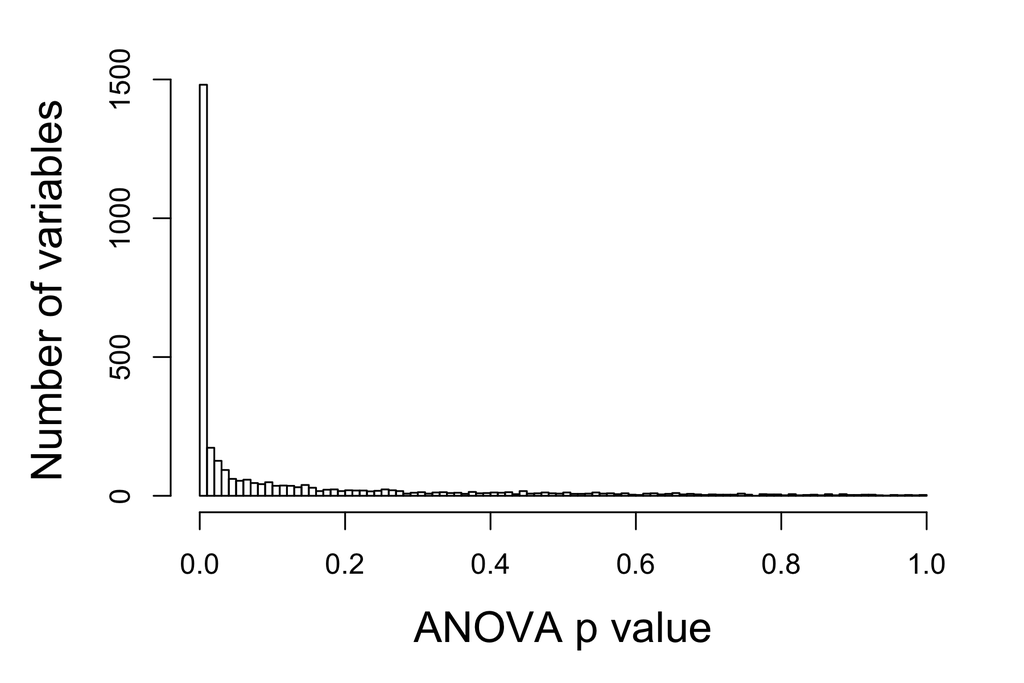

**Figure 1.** Distribution of ANOVA p values. Number of variables with p values within each 0.01 interval.

## 3.2 Select variables

Significant variables were selected using the following criteria:

- Select variables with ANOVA p values less than **10<sup>-5</sup>**
- Stop if the number of remaining variables is between **100** and **2000**, else
  - if the number remaining variable is less than 100, select the top 100 variables with the smallest p values
  - if the number remaining variable is greater than 2000, select the top 2000 variables with the smallest p values

*[Go to project home](http://www.ncbi.nlm.nih.gov/geo/query/acc.cgi?acc=GSE67426)*

# 4 Heatmap

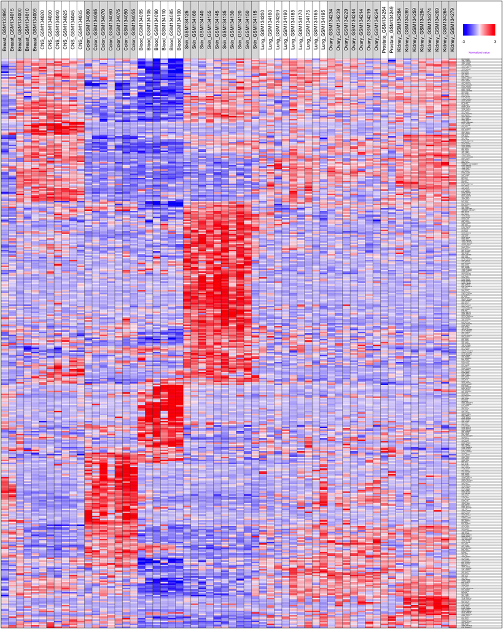

**Figure 2.** Color-coded data of selected variables different across sample groups (red = higher). Variables (rows) were clustered based on their correlation to each other and samples were arranged by groups.

*[Go to project home](http://www.ncbi.nlm.nih.gov/geo/query/acc.cgi?acc=GSE67426)*

# 5 Appendix

Check out the **[RoCA home page](http://zhezhangsh.github.io/RoCA)** for more information.

## 5.1 Reproduce this report

To reproduce this report:

1. Find the data analysis template you want to use and an example of its pairing YAML file [here](https://github.com/zhezhangsh/RoCA/wiki/Templates-and-examples) and download the YAML example to your working directory
2. To generate a new report using your own input data and parameter, edit the following items in the YAML file:
   - *output* : where you want to put the output files
   - *home* : the URL if you have a home page for your project
   - *analyst* : your name
   - *description* : background information about your project, analysis, etc.
   - *input* : where are your input data, read instruction for preparing them
   - *parameter* : parameters for this analysis; read instruction about how to prepare input data
3. Run the code below within *R Console* or *RStudio*, preferablly with a new R session:

```r
if (!require(devtools)) { install.packages('devtools'); require(devtools); }
if (!require(RCurl)) { install.packages('RCurl'); require(RCurl); }
if (!require(RoCA)) { install_github('zhezhangsh/RoCAR'); require(RoCA); }

CreateReport(filename.yaml);  # filename.yaml is the YAML file you just downloaded and edited for your analysis
```

If there is no complaint, go to the *output* folder and open the *index.html* file to view report.

*[Go to project home](http://www.ncbi.nlm.nih.gov/geo/query/acc.cgi?acc=GSE67426)*

*END OF DOCUMENT*